# Project Python Foundations: FoodHub Data Analysis

**Marks: 60**

### Context

The number of restaurants in New York is increasing day by day. Lots of students and busy professionals rely on those restaurants due to their hectic lifestyles. Online food delivery service is a great option for them. It provides them with good food from their favorite restaurants. A food aggregator company FoodHub offers access to multiple restaurants through a single smartphone app.

The app allows the restaurants to receive a direct online order from a customer. The app assigns a delivery person from the company to pick up the order after it is confirmed by the restaurant. The delivery person then uses the map to reach the restaurant and waits for the food package. Once the food package is handed over to the delivery person, he/she confirms the pick-up in the app and travels to the customer's location to deliver the food. The delivery person confirms the drop-off in the app after delivering the food package to the customer. The customer can rate the order in the app. The food aggregator earns money by collecting a fixed margin of the delivery order from the restaurants.

### Objective

The food aggregator company has stored the data of the different orders made by the registered customers in their online portal. They want to analyze the data to get a fair idea about the demand of different restaurants which will help them in enhancing their customer experience. Suppose you are hired as a Data Scientist in this company and the Data Science team has shared some of the key questions that need to be answered. Perform the data analysis to find answers to these questions that will help the company to improve the business.

### Data Description

The data contains the different data related to a food order. The detailed data dictionary is given below.

### Data Dictionary

- order_id: Unique ID of the order
- customer_id: ID of the customer who ordered the food
- restaurant_name: Name of the restaurant
- cuisine_type: Cuisine ordered by the customer
- cost: Cost of the order
- day_of_the_week: Indicates whether the order is placed on a weekday or weekend (The weekday is from Monday to Friday and the weekend is Saturday and Sunday)
- rating: Rating given by the customer out of 5
- food_preparation_time: Time (in minutes) taken by the restaurant to prepare the food. This is calculated by taking the difference between the timestamps of the restaurant's order confirmation and the delivery person's pick-up confirmation.
- delivery_time: Time (in minutes) taken by the delivery person to deliver the food package. This is calculated by taking the difference between the timestamps of the delivery person's pick-up confirmation and drop-off information

### Let us start by importing the required libraries

```python
# import libraries for data manipulation
import numpy as np
import pandas as pd

# import libraries for data visualization
import matplotlib.pyplot as plt
import seaborn as sns
```

### Understanding the structure of the data

```python
from google.colab import drive
drive.mount('/content/drive')
```

```python
# read the data
df = pd.read_csv('/content/drive/MyDrive/Colab Notebooks/foodhub_order.csv')
# returns the first 5 rows
df.head()
```

|  | order_id | customer_id | restaurant_name | cuisine_type | cost_of_the_order | day_of_the_week | rating | food_preparation_time | delivery_time |
| --- | --- | --- | --- | --- | --- | --- | --- | --- | --- |
| 0 | 1477147 | 337525 | Hangawi | Korean | 30.75 | Weekend | Not given | 25 | 20 |
| 1 | 1477685 | 358141 | Blue Ribbon Sushi Izakaya | Japanese | 12.08 | Weekend | Not given | 25 | 23 |
| 2 | 1477070 | 66393 | Cafe Habana | Mexican | 12.23 | Weekday | 5 | 23 | 28 |
| 3 | 1477334 | 106968 | Blue Ribbon Fried Chicken | American | 29.20 | Weekend | 3 | 25 | 15 |
| 4 | 1478249 | 76942 | Dirty Bird to Go | American | 11.59 | Weekday | 4 | 25 | 24 |

#### Observations:

The DataFrame has 9 columns as mentioned in the Data Dictionary. Data in each row corresponds to the order placed by a customer.

### **Question 1:** How many rows and columns are present in the data? [0.5 mark]

```python
#returns number of rows and columns
df.shape

rows, columns = df.shape
print("Number of rows:", rows)
print("Number of columns:", columns)
```

```
Number of rows: 1898
Number of columns: 9
```

#### Observations:

- There are 1898 rows and 9 columns present in the data.

### **Question 2:** What are the datatypes of the different columns in the dataset? (The info() function can be used) [0.5 mark]

```python
#checking the datatype of columns
df.info()
```

```
<class 'pandas.core.frame.DataFrame'>
RangeIndex: 1898 entries, 0 to 1897
Data columns (total 9 columns):
 #   Column                 Non-Null Count  Dtype
---  ------                 --------------  -----
 0   order_id               1898 non-null   int64
 1   customer_id            1898 non-null   int64
 2   restaurant_name        1898 non-null   object
 3   cuisine_type           1898 non-null   object
 4   cost_of_the_order      1898 non-null   float64
 5   day_of_the_week        1898 non-null   object
 6   rating                 1898 non-null   object
 7   food_preparation_time  1898 non-null   int64
 8   delivery_time          1898 non-null   int64
dtypes: float64(1), int64(4), object(4)
memory usage: 133.6+ KB
```

```python
#looking into the unique values in the rating column to see why it is an object dtype
df['rating'].unique()
```

```
array(['Not given', '5', '3', '4'], dtype=object)
```

#### Observations:

- The columns **restaurant_name, cuisine_type, day_of_the_week** and **rating** are of the object type. Rating should have an int64 or float dtype if it is based on a number scale; however, the 'Not given' entries return it as an object dtype.
- The columns **order_id, customer_id, food_preparation_time** and **delivery_time** are of the integer type.
- The column **cost_of_the_order** is of the float type.

### **Question 3:** Are there any missing values in the data? If yes, treat them using an appropriate method. [1 mark]

```python
#checking for missing values
df.isnull().sum()
```

|  | 0 |
| --- | --- |
| order_id | 0 |
| customer_id | 0 |
| restaurant_name | 0 |
| cuisine_type | 0 |
| cost_of_the_order | 0 |
| day_of_the_week | 0 |
| rating | 0 |
| food_preparation_time | 0 |
| delivery_time | 0 |

**dtype:** int64

#### Observations:

- There are no missing values in the dataset. However, as previously mentioned, the rating column has 'Not given' reviews.

### **Question 4:** Check the statistical summary of the data. What is the minimum, average, and maximum time it takes for food to be prepared once an order is placed? [2 marks]

```python
#returns the statistical summary of the data and transpose the result
df.describe().T
```

|  | count | mean | std | min | 25% | 50% | 75% | max |
| --- | --- | --- | --- | --- | --- | --- | --- | --- |
| order_id | 1898.0 | 1.477496e+06 | 548.049724 | 1476547.00 | 1477021.25 | 1477495.50 | 1.477970e+06 | 1478444.00 |
| customer_id | 1898.0 | 1.711685e+05 | 113698.139743 | 1311.00 | 77787.75 | 128600.00 | 2.705250e+05 | 405334.00 |
| cost_of_the_order | 1898.0 | 1.649885e+01 | 7.483812 | 4.47 | 12.08 | 14.14 | 2.229750e+01 | 35.41 |
| food_preparation_time | 1898.0 | 2.737197e+01 | 4.632481 | 20.00 | 23.00 | 27.00 | 3.100000e+01 | 35.00 |
| delivery_time | 1898.0 | 2.416175e+01 | 4.972637 | 15.00 | 20.00 | 25.00 | 2.800000e+01 | 33.00 |

#### Observations:

- There are 1898 orders.
- The cost of the order ranges from $4.47 - $35.41 with an average of $16.50. It has a Q1 equal to $12.08 and a Q3 equal to $22.30.
- The time it takes for the food to be prepared once an order is placed ranges from 20 - 35 minutes with an average of 27 minutes. It has a Q1 equal to 23 minutes and a Q3 equal to 31 minutes.
- The time it takes for the food to be delivered ranges from 15 - 33 minutes with an average of 24 minutes. It has a Q1 equal to 20 minutes and a Q3 equal to 28 minutes.

### **Question 5:** How many orders are not rated? [1 mark]

```python
#returns the unique values of the rating column
df['rating'].unique()
```

```
array(['Not given', '5', '3', '4'], dtype=object)
```

```python
#filtering the data to show only the orders with 'Not given' ratings
df[df['rating'] == 'Not given']
```

|  | order_id | customer_id | restaurant_name | cuisine_type | cost_of_the_order | day_of_the_week | rating | food_preparation_time | delivery_time |
| --- | --- | --- | --- | --- | --- | --- | --- | --- | --- |
| 0 | 1477147 | 337525 | Hangawi | Korean | 30.75 | Weekend | Not given | 25 | 20 |
| 1 | 1477685 | 358141 | Blue Ribbon Sushi Izakaya | Japanese | 12.08 | Weekend | Not given | 25 | 23 |
| 6 | 1477894 | 157711 | The Meatball Shop | Italian | 6.07 | Weekend | Not given | 28 | 21 |
| 10 | 1477895 | 143926 | Big Wong Restaurant _¤¾Ñ¼ | Chinese | 5.92 | Weekday | Not given | 34 | 28 |
| 14 | 1478198 | 62667 | Lucky's Famous Burgers | American | 12.13 | Weekday | Not given | 23 | 30 |
| ... | ... | ... | ... | ... | ... | ... | ... | ... | ... |
| 1887 | 1476873 | 237616 | Shake Shack | American | 5.82 | Weekend | Not given | 26 | 30 |
| 1891 | 1476981 | 138586 | Shake Shack | American | 5.82 | Weekend | Not given | 22 | 28 |
| 1892 | 1477473 | 97838 | Han Dynasty | Chinese | 29.15 | Weekend | Not given | 29 | 21 |
| 1895 | 1477819 | 35309 | Blue Ribbon Sushi | Japanese | 25.22 | Weekday | Not given | 31 | 24 |
| 1897 | 1478056 | 120353 | Blue Ribbon Sushi | Japanese | 19.45 | Weekend | Not given | 28 | 24 |

736 rows × 9 columns

```python
#sum all the rows with 'Not given'ratings
not_rated = (df['rating'] == 'Not given').sum()
print(f"Number of orders not rated: {not_rated}")
```

```
Number of orders not rated: 736
```

#### Observations:

- The unique values of the **rating** column are *'Not given', '5', '3' and '4'*.
- From this, we are able to determine the number of orders labeled *'Not given'*, which are 736 orders.

### Exploratory Data Analysis (EDA)

### **Question 6:** Explore all the variables and provide observations on their distributions. (Generally, histograms, boxplots, countplots, etc. are used for univariate exploration.) [9 marks]

```python
#determing the total number of orders in the dataset
total_number_of_orders = df['order_id'].value_counts().sum()
print(f"The total number of orders is: {total_number_of_orders}")
```

```
The total number of orders is: 1898
```

```python
#return the first 10 most frequent customers
df['customer_id'].value_counts().head(10)
```

| customer_id | count |
| --- | --- |
| 52832 | 13 |
| 47440 | 10 |
| 83287 | 9 |
| 250494 | 8 |
| 259341 | 7 |
| 82041 | 7 |
| 65009 | 7 |
| 276192 | 7 |
| 97079 | 6 |
| 97991 | 6 |

**dtype:** int64

#### Observations on Customer ID:

- The table shows the top 10 customers based on their order count.

```python
#return the first 10 most popular restaurants
df['restaurant_name'].value_counts().head(10)
```

| restaurant_name | count |
| --- | --- |
| Shake Shack | 219 |
| The Meatball Shop | 132 |
| Blue Ribbon Sushi | 119 |
| Blue Ribbon Fried Chicken | 96 |
| Parm | 68 |
| RedFarm Broadway | 59 |
| RedFarm Hudson | 55 |
| TAO | 49 |
| Han Dynasty | 46 |
| Blue Ribbon Sushi Bar & Grill | 44 |

**dtype:** int64

#### Observations on Restaurant Name:

- The table shows the top 10 most famous restaurant from the dataset.

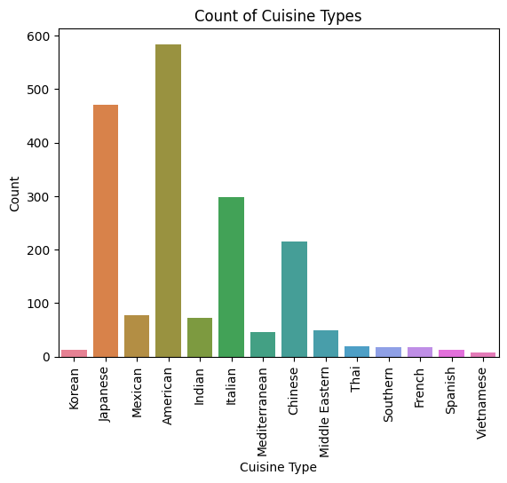

```python
sns.countplot(data=df, x='cuisine_type', hue='cuisine_type')
plt.xticks(rotation=90)
plt.xlabel('Cuisine Type')
plt.ylabel('Count')
plt.title('Count of Cuisine Types');
```

#### Observations on Cuisine Type:

- The top 3 most popular cuisine types based on the bar graph above are: *American, Japanese* and *Italian*.

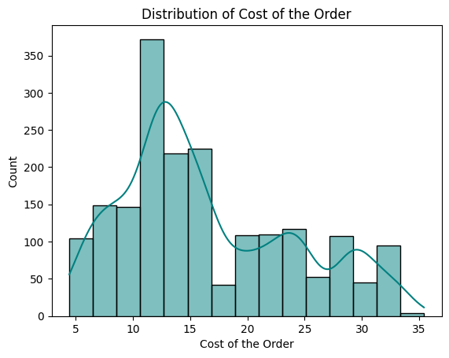

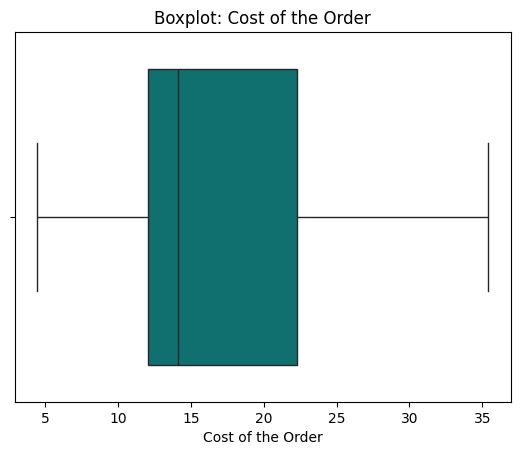

```python
sns.histplot(data=df, x='cost_of_the_order', bins=15, color='teal', kde=True)
plt.xlabel('Cost of the Order')
plt.title('Distribution of Cost of the Order')
plt.show();

sns.boxplot(data=df, x='cost_of_the_order', color='teal')
plt.xlabel('Cost of the Order')
plt.title('Boxplot: Cost of the Order')
plt.show();
```

#### Observations of Cost of the Order:

- The distribution plot is partially right-skewed. In other words, orders at a lower cost are more popular than those orders at higher costs.
- The boxplot has a positive skew. This plot reveals that the range of overall costs extends from $5 to $35 without any outliers. Majority of the costs lie around the $10 - $25 range. As shown by the median (middle line inside the box), 50% of the orders have a cost around $15.

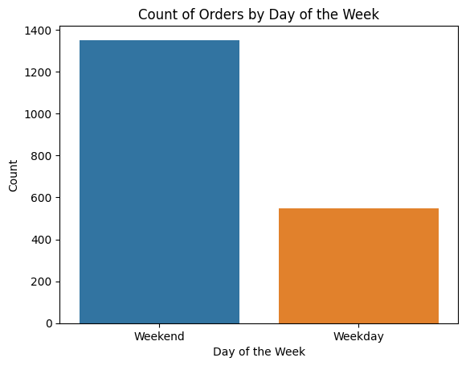

```python
sns.countplot(data=df, x='day_of_the_week', hue= 'day_of_the_week')
plt.xlabel('Day of the Week')
plt.ylabel('Count')
plt.title('Count of Orders by Day of the Week');
```

#### Observations on Day of the Week:

- The bar graph reveals that more orders are placed on weekends versus weekdays.

```python
#counting each unique value in the ratings column
rating_counts = df['rating'].value_counts()
print(rating_counts)
```

```
rating
Not given    736
5            588
4            386
3            188
Name: count, dtype: int64
```

```python
#addings all rating values together
total_ratings = 736+588+386+188

#determing the percent of unrated orders
not_given_rating = round((736/total_ratings)*100, 2)
print(f"The percentage of unrated orders is: {not_given_rating}%")
```

```
The percentage of unrated orders is: 38.78%
```

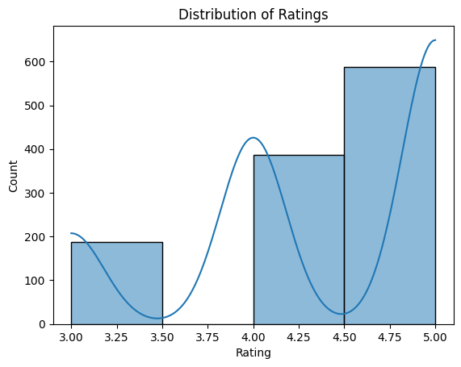

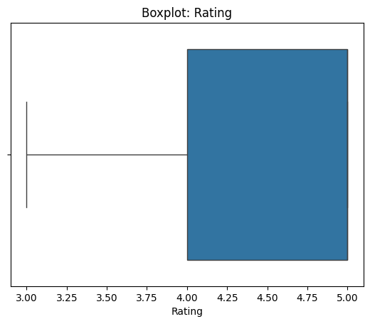

```python
#converting the 'Not given' ratings into numerical data to perform EDA without trouble
dfr = pd.to_numeric(df['rating'], errors='coerce')
dfr = pd.DataFrame(dfr)

sns.histplot(data=dfr, x='rating', bins=4, kde = True)
plt.xlabel('Rating')
plt.title('Distribution of Ratings')
plt.show();

sns.boxplot(data=dfr, x='rating')
plt.xlabel('Rating')
plt.title('Boxplot: Rating')
plt.show();
```

#### Observations on Ratings:

- There are a total of 1898 ratings with 38.78% of those being unrated.
- Excluding these unrated values from the data, the rating values lie within the 3.0 - 5.0 range. However, there is a frequency decline of ratings within the 3.5 - 4.0 range meaning that there are not many ratings that given here.
- There is a higher count of ratings in the 4.0 - 5.0 range, which could imply that customers have had positive experiences with their orders.

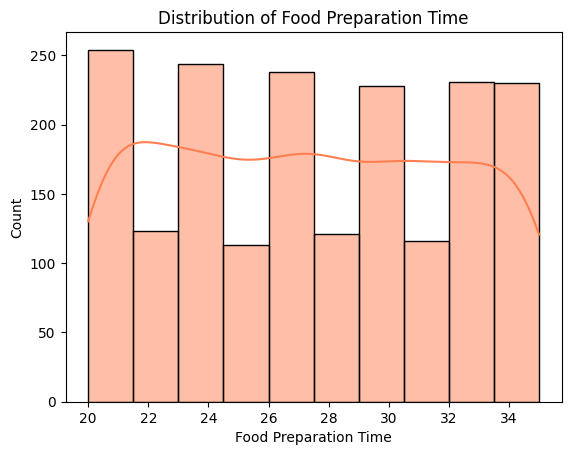

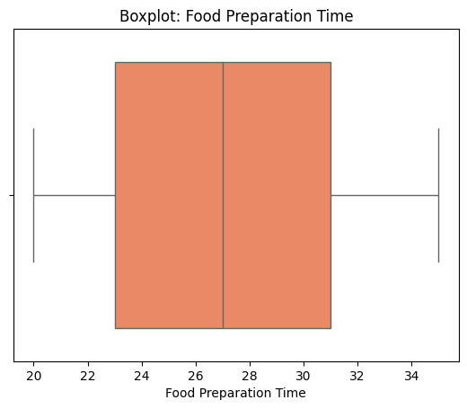

```python
sns.histplot(data= df, x='food_preparation_time',bins= 10, kde= True, color='coral')
plt.title('Distribution of Food Preparation Time')
plt.xlabel('Food Preparation Time')
plt.show();

sns.boxplot(data=df, x='food_preparation_time', color= 'coral')
plt.xlabel('Food Preparation Time')
plt.title('Boxplot: Food Preparation Time')
plt.show();
```

#### Observations on Food Preparation Time:

- The KDE (Kernel Density Estimation) line in our distribution chart reveals that the food preparation time distribution is quite even.
- The food preparation time ranges overall from 20 - 35 minutes. Majority of the food preparation time lies within 23 - 31 minutes while having a median time of 27 minutes. Without outliers in the data, the food preparation time is consistent.

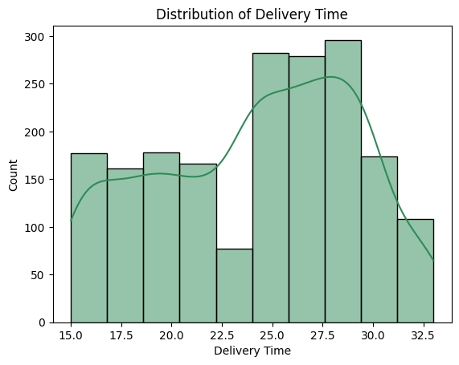

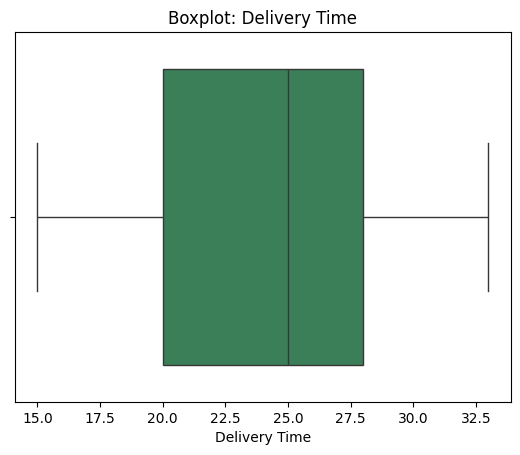

```python
sns.histplot(data=df, x='delivery_time', bins= 10, kde= True, color='seagreen')
plt.title('Distribution of Delivery Time')
plt.xlabel('Delivery Time')
plt.show();

sns.boxplot(data=df, x='delivery_time', color= 'seagreen')
plt.xlabel('Delivery Time')
plt.title('Boxplot: Delivery Time')
plt.show();
```

### **Question 7**: Which are the top 5 restaurants in terms of the number of orders received? [1 mark]

```python
#returns top 10 restaurants
df['restaurant_name'].value_counts().head(10)
```

| restaurant_name | count |
| --- | --- |
| Shake Shack | 219 |
| The Meatball Shop | 132 |
| Blue Ribbon Sushi | 119 |
| Blue Ribbon Fried Chicken | 96 |
| Parm | 68 |
| RedFarm Broadway | 59 |
| RedFarm Hudson | 55 |
| TAO | 49 |
| Han Dynasty | 46 |
| Blue Ribbon Sushi Bar & Grill | 44 |

**dtype:** int64

```python
top_5_restaurants = df['restaurant_name'].value_counts().head(5)
print(top_5_restaurants)
```

```
restaurant_name
Shake Shack                  219
The Meatball Shop            132
Blue Ribbon Sushi            119
Blue Ribbon Fried Chicken     96
Parm                          68
Name: count, dtype: int64
```

#### Observations:

- The top 5 restaurants in terms of the number of orders received are *Shake Shack, The Meatball Shop, Blue Ribbon Sushi, Blue Ribbon Fried Chicken* and *Parm*.

### **Question 8**: Which is the most popular cuisine on weekends? [1 mark]

```python
#filtering the dataframe to show just the 'weekend' entries on 'day_of_the_week' column
weekend_df = df[df['day_of_the_week'] == 'Weekend']

#return a count of the occurences for each cuisine type
popular_on_weekends = weekend_df['cuisine_type'].value_counts()
print(popular_on_weekends)
```

```
cuisine_type
American          415
Japanese          335
Italian           207
Chinese           163
Mexican            53
Indian             49
Mediterranean      32
Middle Eastern     32
Thai               15
French             13
Korean             11
Southern           11
Spanish            11
Vietnamese          4
Name: count, dtype: int64
```

#### Observations:

- After filtering the dataframe to show us results only on the day of the week that is equivalent to *'Weekend'*, the data is organized by count of *'cuisine_type'*.
- The resulting data shows that American cuisine is the most popular cuisine on the weekends.

### **Question 9**: What percentage of the orders cost more than 20 dollars? [2 marks]

```python
#filtering the cost of orders > $20
more_than_20 = df[df['cost_of_the_order'] > 20]
#return number of rows in the new dataframe
more_than_20.shape[0]
```

```
555
```

```python
#return number of rows in the original dataframe
df.shape[0]
```

```
1898
```

```python
#obtain the percent of orders that cost more than > $20
round((more_than_20.shape[0] / df.shape[0]) * 100,2)
```

```
29.24
```

#### Observations:

- The dataset was filtered to show orders that cost more than $20 then divided by the overall number of orders times 100 to showcase our result.
- The percentage of the orders that cost more than $20 is 29.24%.

### **Question 10**: What is the mean order delivery time? [1 mark]

```python
#calculate the average for delivery time
mean = df['delivery_time'].mean()
print(mean)

#rounding the mean df by two decimal places
rounded_mean = round(mean, 2)
print(rounded_mean)
```

```
24.161749209694417
24.16
```

#### Observations:

- The mean order delivery time around 24 minutes.

### **Question 11:** The company has decided to give 20% discount vouchers to the top 5 most frequent customers. Find the IDs of these customers and the number of orders they placed. [1 mark]

```python
#grouping the df with unique customer IDs and for each customer ID it returns the number of order IDs to identify the top 5 most frequent customers
df.groupby('customer_id')['order_id'].count().sort_values(ascending=False).head()
```

| customer_id | order_id |
| --- | --- |
| 52832 | 13 |
| 47440 | 10 |
| 83287 | 9 |
| 250494 | 8 |
| 65009 | 7 |

**dtype:** int64

```python
#returns the top 10 most frequent customers
df.groupby('customer_id')['order_id'].count().sort_values(ascending=False).head(10)
```

| customer_id | order_id |
| --- | --- |
| 52832 | 13 |
| 47440 | 10 |
| 83287 | 9 |
| 250494 | 8 |
| 65009 | 7 |
| 82041 | 7 |
| 259341 | 7 |
| 276192 | 7 |
| 60052 | 6 |
| 115213 | 6 |

**dtype:** int64

#### Observations:

- At first, it appears that customers: **52832, 47440, 83287, 250494** and **65009** are the top 5 most frequent customers.
- However, when expanding the data frame to show us the top 10 most frequent customers, we can see there is a 4-way tie for the 5th highest order count: **65009, 82041, 259341** and **276192.**
- Therefore, the top 5 most frequent customers--including those in a 4-way tie are: **52832, 47440, 83287, 250494, 65009, 82041, 259341** and **276192.**
- In order to break the tie, another parameter must be utilized to determine the top 5 most frequent customers. Otherwise, the company can choose to give the 20% discount to the 8 customers.

### **Question 12**: Perform a multivariate analysis to explore relationships between the important variables in the dataset. (It is a good idea to explore relations between numerical variables as well as relations between numerical and categorical variables) [10 marks]

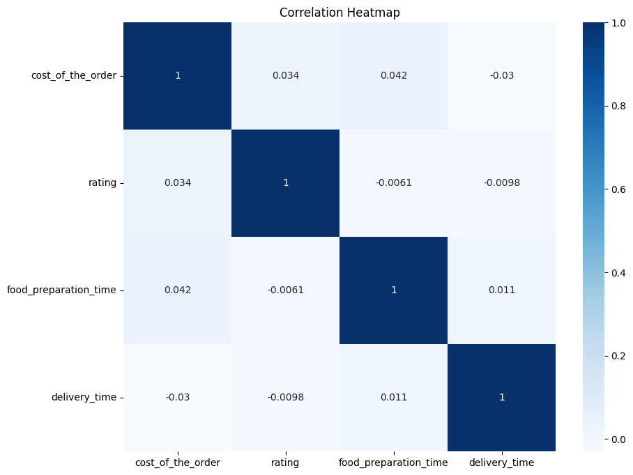

```python
#converting the 'Not given' ratings into numerical data
df['rating'] = pd.to_numeric(df['rating'], errors='coerce')

#creating a list that contains only the columns with numerical data
numeric_columns = ['cost_of_the_order', 'rating', 'food_preparation_time', 'delivery_time']

#calculate the correlation matrix of the numerical columns
corr = df[numeric_columns].corr()
plt.figure(figsize=(10, 8))
sns.heatmap(data=corr, annot=True, cmap='Blues')
plt.title('Correlation Heatmap')
plt.xticks(rotation=0)
plt.yticks(rotation=0)
plt.show()
```

#### Observations:

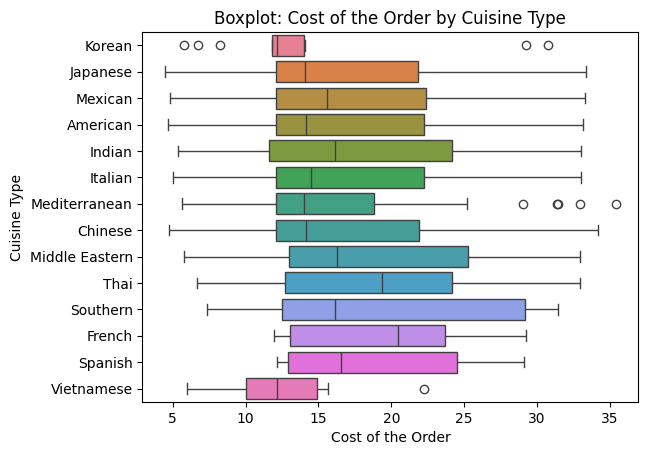

```python
sns.boxplot(data=df, x='cost_of_the_order', y='cuisine_type', hue= 'cuisine_type')
plt.xlabel('Cost of the Order')
plt.ylabel('Cuisine Type')
plt.title('Boxplot: Cost of the Order by Cuisine Type')
plt.show();
```

#### Observations:

- There is a wide distribution of median costs amongst the cuisine types. *Vietnamese* cuisine has the lowest median cost while *French* cuisine has the highest median cost.
- *Korean, Vietnamese* and *Mediterranean* cuisines have outliers -- out of range low or high-cost orders.
- Majority of the cuisines have a wide range of costs, which implies that they supply to customers of different economical status.

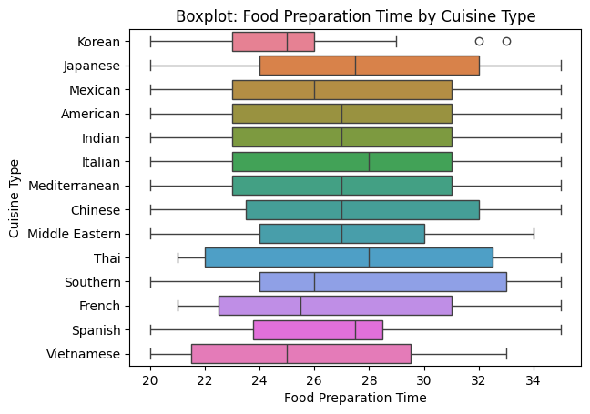

```python
sns.boxplot(data=df, x= 'food_preparation_time', y= 'cuisine_type', hue= 'cuisine_type')
plt.title('Boxplot: Food Preparation Time by Cuisine Type')
plt.xlabel('Food Preparation Time')
plt.ylabel('Cuisine Type');
```

#### Observations:

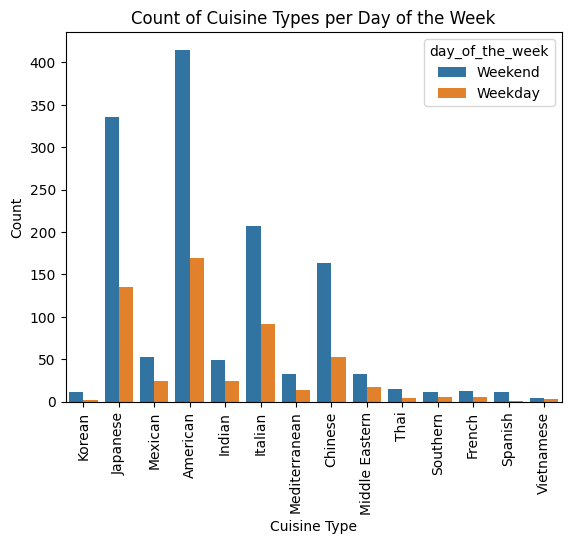

```python
sns.countplot(data=df, x= 'cuisine_type', hue= 'day_of_the_week')
plt.xlabel('Cuisine Type')
plt.xticks(rotation=90)
plt.ylabel('Count')
plt.title('Count of Cuisine Types per Day of the Week');
```

#### Observations:

- There is a higher number of orders placed on weekends versus weekdays for all cuisine types. A probable cause for this is that customers might have more time to scout restaurants on weekends.
- The popularity pattern on weekdays is parallel to that of the weekends.

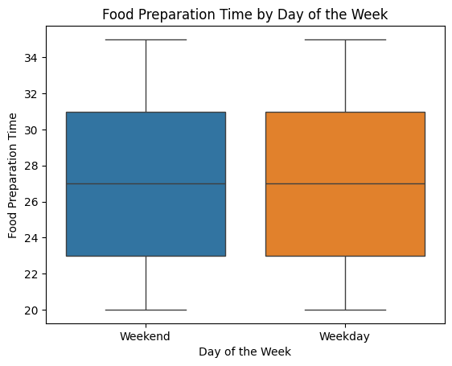

```python
sns.boxplot(data=df, x='day_of_the_week', y= 'food_preparation_time', hue= 'day_of_the_week')
plt.xlabel('Day of the Week')
plt.ylabel('Food Preparation Time')
plt.title('Food Preparation Time by Day of the Week');
```

#### Observations:

- Food preparation time on weekdays is parallel to that of the weekends.

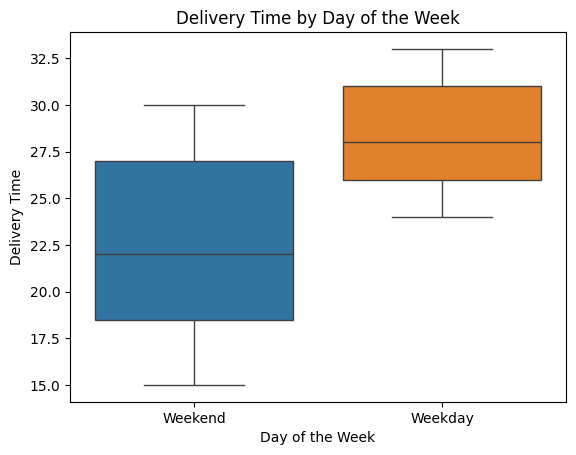

```python
sns.boxplot(data=df, x='day_of_the_week', y= 'delivery_time', hue= 'day_of_the_week')
plt.xlabel('Day of the Week')
plt.ylabel('Delivery Time')
plt.title('Delivery Time by Day of the Week');
```

#### Observations:

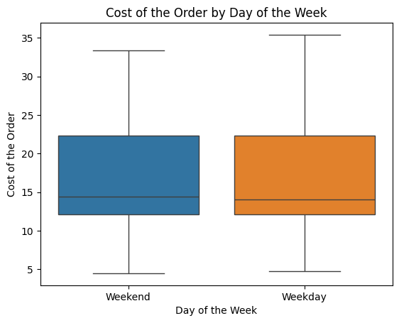

```python
sns.boxplot(data=df, x= 'day_of_the_week', y= 'cost_of_the_order', hue= 'day_of_the_week')
plt.xlabel('Day of the Week')
plt.ylabel('Cost of the Order')
plt.title('Cost of the Order by Day of the Week');
```

### **Question 13:** The company wants to provide a promotional offer in the advertisement of the restaurants. The condition to get the offer is that the restaurants must have a rating count of more than 50 and the average rating should be greater than 4. Find the restaurants fulfilling the criteria to get the promotional offer. [3 marks]

```python
#converting the 'Not given' ratings into numerical data
df['rating'] = pd.to_numeric(df['rating'], errors='coerce')
```

```python
df['rating']
```

|  | rating |
| --- | --- |
| 0 | NaN |
| 1 | NaN |
| 2 | 5.0 |
| 3 | 3.0 |
| 4 | 4.0 |
| ... | ... |
| 1893 | 5.0 |
| 1894 | 5.0 |
| 1895 | NaN |
| 1896 | 5.0 |
| 1897 | NaN |

1898 rows × 1 columns

**dtype:** float64

```python
#filter data of restaurants with more than a 50 rating count
df1 = df.groupby('restaurant_name')['rating'].count()

count_ratings = df1[df1 > 50].reset_index()
print(count_ratings)
```

```
             restaurant_name  rating
0  Blue Ribbon Fried Chicken      64
1          Blue Ribbon Sushi      73
2                Shake Shack     133
3          The Meatball Shop      84
```

```python
#filter data of restaurants with a rating average > 4
df2 = df.groupby('restaurant_name')['rating'].mean()

avg_ratings = round(df2[df2 > 4].reset_index(),2)
print(avg_ratings)
```

```
              restaurant_name  rating
0                  'wichcraft    5.00
1                   12 Chairs    4.50
2                   67 Burger    5.00
3                        Amma    4.50
4          Anjappar Chettinad    5.00
..                        ...     ...
105                   Yama 49    5.00
106  Yama Japanese Restaurant    4.50
107                da Umberto    5.00
108          ilili Restaurant    4.15
109                 indikitch    4.50

[110 rows x 2 columns]
```

```python
#merging the previously created dataframes to filter the restaurants that meet both criteria
promo_restaurants = pd.merge(count_ratings, avg_ratings, on='restaurant_name')

print(promo_restaurants)
```

```
             restaurant_name  rating_x  rating_y
0  Blue Ribbon Fried Chicken        64      4.33
1          Blue Ribbon Sushi        73      4.22
2                Shake Shack       133      4.28
3          The Meatball Shop        84      4.51
```

```python
promo_restaurants = pd.merge(count_ratings, avg_ratings, on='restaurant_name')

#renaming the columns
promo_restaurants = promo_restaurants.rename(columns={'rating_x': 'rating_count', 'rating_y': 'avg_rating'})
print(promo_restaurants)
```

```
             restaurant_name  rating_count  avg_rating
0  Blue Ribbon Fried Chicken            64        4.33
1          Blue Ribbon Sushi            73        4.22
2                Shake Shack           133        4.28
3          The Meatball Shop            84        4.51
```

#### Observations:

- The restaurants that fulfill the criteria of having a rating count of more than 50 and the average rating greater than 4 are: **Blue Ribbon Fried Chicken, Blue Ribbon Sushi, Shake Shack** and **The Meatball Shop**.

### **Question 14:** The company charges the restaurant 25% on the orders having cost greater than 20 dollars and 15% on the orders having cost greater than 5 dollars. Find the net revenue generated by the company across all orders. [3 marks]

```python
#create a conditional statement with the criteria mentioned
def cost(x):
  if x > 20:
    return x * 0.25
  elif x > 5:
    return x * 0.15
  else:
    return 0
```

```python
#creating a function that applies the cost function to each value of the cost of the order column and assinging it to the revenue column
df['revenue'] = df['cost_of_the_order'].apply(cost)
```

```python
#calculate the total revenue
net_revenue = round(df['revenue'].sum(), 2)
print(f"${net_revenue}")
```

```
$6166.3
```

#### Observations:

- The net revenue generated by the company across all orders is $6,166.30.

### **Question 15:** The company wants to analyze the total time required to deliver the food. What percentage of orders take more than 60 minutes to get delivered from the time the order is placed? (The food has to be prepared and then delivered.) [2 marks]

```python
df['food_preparation_time']
```

|  | food_preparation_time |
| --- | --- |
| 0 | 25 |
| 1 | 25 |
| 2 | 23 |
| 3 | 25 |
| 4 | 25 |
| ... | ... |
| 1893 | 31 |
| 1894 | 31 |
| 1895 | 31 |
| 1896 | 23 |
| 1897 | 28 |

1898 rows × 1 columns

**dtype:** int64

```python
df['delivery_time']
```

|  | delivery_time |
| --- | --- |
| 0 | 20 |
| 1 | 23 |
| 2 | 28 |
| 3 | 15 |
| 4 | 24 |
| ... | ... |
| 1893 | 17 |
| 1894 | 19 |
| 1895 | 24 |
| 1896 | 31 |
| 1897 | 24 |

1898 rows × 1 columns

**dtype:** int64

```python
#creating a new column that adds the food prep. time and the delivery time
df['total_time'] = df['food_preparation_time'] + df['delivery_time']
```

```python
df['total_time']
```

|  | total_time |
| --- | --- |
| 0 | 45 |
| 1 | 48 |
| 2 | 51 |
| 3 | 40 |
| 4 | 49 |
| ... | ... |
| 1893 | 48 |
| 1894 | 50 |
| 1895 | 55 |
| 1896 | 54 |
| 1897 | 52 |

1898 rows × 1 columns

**dtype:** int64

```python
#filtering the total time column to show times > 60 minutes
more_than_60 = df[df['total_time'] > 60]
more_than_60.shape[0]
```

```
200
```

```python
df.shape[0]
```

```
1898
```

```python
#determing the percentage of orders that take > 60 minutes
round((more_than_60.shape[0]/df.shape[0])*100, 2)
```

```
10.54
```

- Around 10.54% of orders take more than 60 minutes to get delivered from the time the order is placed.

#### Observations:

### **Question 16:** The company wants to analyze the delivery time of the orders on weekdays and weekends. How does the mean delivery time vary during weekdays and weekends? [2 marks]

```python
df['delivery_time']
```

|  | delivery_time |
| --- | --- |
| 0 | 20 |
| 1 | 23 |
| 2 | 28 |
| 3 | 15 |
| 4 | 24 |
| ... | ... |
| 1893 | 17 |
| 1894 | 19 |
| 1895 | 24 |
| 1896 | 31 |
| 1897 | 24 |

1898 rows × 1 columns

**dtype:** int64

```python
df['day_of_the_week']
```

|  | day_of_the_week |
| --- | --- |
| 0 | Weekend |
| 1 | Weekend |
| 2 | Weekday |
| 3 | Weekend |
| 4 | Weekday |
| ... | ... |
| 1893 | Weekend |
| 1894 | Weekend |
| 1895 | Weekday |
| 1896 | Weekday |
| 1897 | Weekend |

1898 rows × 1 columns

**dtype:** object

```python
#filtering to show rows that meet the 'weekend' criteria
weekends = df[df['day_of_the_week'] == 'Weekend']
#returns average of delivery time on weekends
delivery_weekends_mean = weekends['delivery_time'].mean()

rounded_weekends = round(delivery_weekends_mean, 2)
print(rounded_weekends)
```

```
22.47
```

```python
#filtering to show rows that meet the 'weekday' criteria
weekdays = df[df['day_of_the_week'] == 'Weekday']
#returns average of delivery time on weekdays
delivery_weekdays_mean = weekdays['delivery_time'].mean()

rounded_weekdays = round(delivery_weekdays_mean, 2)
print(rounded_weekdays)
```

```
28.34
```

#### Observations:

- The mean delivery time for weekdays is about 28 minutes while for weekends around 22.5 minutes. There is about a 6 minute difference in mean delivery time between weekdays and weekends.
- One logical explanation as to why the mean delivery time on weekdays is higher is likely due to the vast amount of traffic on weekdays compared to weekends; therefore, delaying the delivery time.

### Conclusion and Recommendations

### **Question 17:** What are your conclusions from the analysis? What recommendations would you like to share to help improve the business? (You can use cuisine type and feedback ratings to drive your business recommendations.) [6 marks]

### Conclusions:

- There are a total of 1898 orders in the dataset, 736 of which are unrated (38.78%).
- Ratings are mainly focused in the 4-5 range, which suggests that customers who have had positive experiences are the main ones using the rating system.
- The top 5 restaurants are *Shake Shack, The Meatball Shop, Blue Ribbon Sushi, Blue Ribbon Fried Chicken* and *Parm*.
- The most popular cuisines are American, Japanese and Italian cuisines and this popularity pattern stays constant across weekdays and weekends.
- Orders at a lower-cost tend to be more popular with the average cost of an order being $16.50. The percentage of the orders that cost more than $20 is 29.24%. The cost of orders do not outstandingly vary between days of the week.
- There are more orders placed on the weekends -- most likely because of weekends being customers' days-off from work.
- Food preparation time is consistent for any day of the week. On the other hand, delivery time is shorter on weekends than weekdays probably as a result of less traffic.
- The net revenue generated by the company across all orders is $6,166.30.

### Recommendations:

- Offer special promotions or discounts to motivate customers to leave ratings. This will lower the amount of 'Not given' ratings and produce a more accurate representation of what the customer base is thinking.
- A loyalty program can be utilized to encourage regular customers to stay with this delivery app.
- As it was previously proven that popularity pattern stays constant across weekdays and weekends, the recommendation is to focus on increasing weekday orders since they have lower counts. To increase weekday sales, it is suggested to feature American, Japanese and Italian cuisines in promotion campaigns.
- Since *Shake Shack, The Meatball Shop, Blue Ribbon Sushi* and *Blue Ribbon Fried Chicken* are the only restaurants that have more than 50 counts of ratings and an average rating greater than 4, they can be utilized for advertisements promoting excellent customer experiences.
- Highlight lower cost meal options through Vietnamese cuisine advertisements as it one of the cuisines on the lower cost end. Utilize Korean cuisine advertisements to promote prompt service for those customers who are always on the go.
- Due to a higher order volume on weekends, it is recommended to recruit more delivery employees to counterbalance this. With this in effect, quicker delivery times can be promoted to increase clientele. Another action that can be taken here is to offer significantly reduced delivery fees on orders over a specific amount (ex. $30) during non-peak traffic hours.
- Identify the root cause as to why 10.54% of orders take more than 60 minutes to get delivered. Although a small percentage, it is a problem in the system that can be improved through simple fixes.
- Weekday delivery times could be improved by mapping the high-traffic areas and adjusting these routes ahead of time.
- Regarding the 20% discount vouchers to the top 5 most frequent customers, a tie-breaker must be implemented for customers sharing the same number of orders if only 5 customers are what the company budgeted for. On the other hand, if budget is not an issue, the company can choose to give the 20% discount to all 8 customers.
- Being that only 29.24% of orders exceed a cost of more than $20, there is room to upsell average order values. One way to go about this is to offer discount promotions that encourage higher spending (ex. "Spend $20, get 10% off").